# Lineární programování

MPC-OMM · přednáška 2

Tomáš Vičar

Ústav biomedicínského inženýrství · FEKT VUT

2026-09-28

## Po dnešku byste měli umět…

Poznat lineární úlohu

Podle čeho se pozná, že problém patří do LP?

Přeložit zadání

Jak ze slovní úlohy vzniknou $A$, $\mathbf b$ a $\mathbf c$?

Číst geometrii

Jak vypadá přípustná oblast a proč je optimum ve vrcholu?

Předat to solveru

Co za nás udělá software — a co za nás nikdo neudělá?

## Kam jsme došli minule

Každá optimalizační úloha má tři části:

- **proměnné** — co můžu měnit;
- **účelová funkce** — co zlepšuji;
- **omezení** — co nesmím porušit.

Body, které splní všechna omezení, tvoří **přípustnou oblast**. Omezení, jež v optimu platí s rovností, je **aktivní** — to ono zastavilo řešení tam, kde je.

U konvexní úlohy je navíc každé lokální optimum zároveň globální.

Skončili jsme u pekárny:

$$\begin{aligned}
\text{maximize}\quad & 14x_1+8x_2 && \text{zisk}\\
\text{subject to}\quad & 0{,}5x_1+0{,}2x_2\leq80 && \text{mouka}\\
& 3x_1+2x_2\leq600 && \text{pec}\\
& x_1,x_2\geq0
\end{aligned}$$

Optimum $\mathbf x^\star=(100,150)$ se ziskem 2600 Kč; obě suroviny padnou beze zbytku, obě omezení jsou aktivní.

Dnes tenhle zápis rozebereme na součástky $\mathbf c$, $A$, $\mathbf b$ — a hlavně se naučíme do něj překládat úlohy, které jsme ještě neviděli.

## 1 · Proč zrovna lineární úlohy

> Když problém dokážeme zapsat jako $\mathbf c^\mathsf T\mathbf x$ a $A\mathbf x\leq \mathbf b$, je hotovo — zbytek udělá solver. Celé umění je v tom zápisu.

## Kdy je úloha lineární?

### Proporcionalita

Dvakrát víc chlebů = dvakrát víc mouky a dvakrát větší zisk. Sazba se nemění: pořád 0,5 kg a 14 Kč na jeden chléb.

$$x_1\;\longmapsto\;2x_1
\qquad\Longrightarrow\qquad
0{,}5\,x_1\;\longmapsto\;2\cdot 0{,}5\,x_1$$

Žádné množstevní slevy, žádné rozjezdové ztráty.

### Aditivita

Chléb a bageta si navzájem nemění spotřebu. Celková mouka je prostý **součet** obou příspěvků.

$$0{,}5\,x_1+0{,}2\,x_2\leq 80$$

Že se dnes pečou i bagety, nezmění, kolik mouky padne na jeden chléb.

Obojí dohromady je definice linearity: $f(\alpha \mathbf x+\beta \mathbf y)=\alpha f(\mathbf x)+\beta f(\mathbf y)$. Prakticky to znamená, že každá proměnná vystupuje **v první mocnině a s konstantním koeficientem** — žádné $x_1x_2$, $x^2$, $\sqrt{x}$, $\log x$ ani skryté „když…, tak…“. A platit to musí pro účelovou funkci **i pro každé omezení**.

## Co linearitu rozbíjí

[figure not shown]

| Lineární | Nelineární — a čím to je |
| --- | --- |
| konstantní cena za kus | množstevní sleva od 40 kg |
| náklad úměrný objemu výroby | fixní náklad za rozjetí šarže |
| dělitelné množství | „buď vyrábím, nebo ne“ (0/1) |
| příspěvky se sčítají | součin proměnných: dávka × doba |
| odezva úměrná dávce | saturace receptoru |

Takové úlohy nejsou ztracené — solvery na ně existují. Platí se ale časem a ztrátou záruk; a část z nich jde chytře přepsat zpátky na LP.

## Proč nám na linearitě záleží

### LP — vyřešený problém

- přípustná oblast je konvexní, takže lokální optimum je rovnou globální;
- optimum stačí hledat mezi vrcholy, ne v celém prostoru;
- solvery dnes běžně počítají úlohy o statisících až milionech proměnných;
- solver spolehlivě pozná i to, že řešení neexistuje.

### Obecná nelineární úloha

- krajina může mít mnoho údolí a nikdo neřekne, které je nejhlubší;
- metoda obvykle najde jen **lokální** optimum a záleží na startovním bodu;
- spolehlivě zvládnutelné velikosti jsou o řády menší;
- „vyřešit libovolnou nelineární úlohu“ je dodnes otevřený problém.

Proto se vyplatí investovat čas do **formulace**: hodina strávená přepsáním úlohy do lineárního tvaru ušetří dny hádání se solverem. Zbytek přednášky je o tom, jak takový zápis vzniká — a co se v něm dá ještě získat zdarma.

## 2 · Řeč matic

> Než začneme překládat slovní zadání do matematiky, potřebujeme slovník. Stačí pět slov: **vektor**, **skalární součin**, **matice**, **součin $A\mathbf x$** a **nerovnost mezi vektory**.

## Vektor a skalární součin

Kam to celé míří: $\min$ $\mathbf c^\mathsf T\mathbf x$ za podmínek $A\mathbf x\leq \mathbf b$, $\mathbf x$$\,\geq0$

### Vektor: seznam čísel

$$\mathbf x=\begin{bmatrix}x_1\\x_2\\\vdots\\x_n\end{bmatrix}\in\mathbb R^n$$

Uspořádaná $n$-tice, psaná jako **sloupec**, tedy matice $n\times1$.

V pekárně je $\mathbf x$ **rozhodnutí** [ks/den] a $\mathbf c=(14,8)$ **koeficienty** zisku [Kč/ks]; první složka je vždy chléb, druhá bageta.

### Skalární součin: jedno číslo

Pro vektory **stejné délky** $\mathbf c,\mathbf x\in\mathbb R^n$

$$\mathbf c^\mathsf T\mathbf x=\sum_{i=1}^{n}c_ix_i=c_1x_1+\dots+c_nx_n .$$

Horní index $^\mathsf T$ je **transpozice**: překlopí sloupec na řádek. Řádek $1\times n$ krát sloupec $n\times1$ dá jedno číslo — proto se píše $\mathbf c^\mathsf T\mathbf x$.

Jinde psáno $\langle \mathbf c,\mathbf x\rangle$ nebo $\mathbf c\cdot \mathbf x$. V pekárně je to celý zisk, tedy 2600 Kč:

$$\mathbf c^\mathsf T\mathbf x^\star=14\cdot100+8\cdot150=2600 .$$

**Značení:** celé vektory tučně malým písmenem ($\mathbf x$, $\mathbf c$, $\mathbf b$), matice velkým ($A$), jednotlivé složky obyčejně ($x_1$, $c_i$). Význam vektoru dává **pořadí a jednotka**: složka $x_1=100$ znamená „sto chlebů denně“. Skalární součin je **celá lineární účelová funkce**; kdyby v zisku vystupovalo $x_1x_2$, žádné $\mathbf c$ neexistuje.

## Matice: tabulka koeficientů

Kam to celé míří: $\min\ \mathbf c^\mathsf T\mathbf x$ za podmínek $A$$\mathbf x\leq \mathbf b$, $\mathbf x\geq0$

Matice $A\in\mathbb R^{m\times n}$ má $m$ řádků a $n$ sloupců; prvek $A_{ij}$ leží v $i$-tém řádku a $j$-tém sloupci — **nejdřív řádek, potom sloupec**. V lineárním programu je $m$ počet omezení a $n$ počet proměnných.

[figure not shown]

Pořadí řádků i sloupců je naše volba — musí ale být stejné v $A$, v $\mathbf b$, v $\mathbf c$ i ve výstupu solveru.

## Dva pohledy na násobení matice vektorem

Kam to celé míří: $\min\ \mathbf c^\mathsf T\mathbf x$ za podmínek $A\mathbf x$$\,\leq \mathbf b$, $\mathbf x\geq0$

$A$ má rozměr $m\times n$, $\mathbf x$ je $n\times1$; výsledek $A\mathbf x$ je proto $m\times1$ — jedno číslo na každý řádek, tedy na každé omezení.

[figure not shown]

Obě čtení dají stejná čísla, ale ptají se jinak. **Po řádcích:** kolik se spotřebuje suroviny $i$? **Po sloupcích:** co k celkové spotřebě přidá jeden další kus výrobku $j$? Druhý pohled je důvod, proč recept jednoho výrobku píšeme do jednoho sloupce.

## Spočítejme to ručně

Kam to celé míří: $\min\ \mathbf c^\mathsf T\mathbf x$ za podmínek $A\mathbf x\leq \mathbf b$, $\mathbf x\geq0$

Dosadíme optimum z minulé přednášky, $\mathbf x^\star=(100,150)$:

$$A\mathbf x^\star=
\begin{bmatrix}0{,}5&0{,}2\\3&2\end{bmatrix}
\begin{bmatrix}100\\150\end{bmatrix}$$

$$\begin{aligned}
\text{mouka:}\quad & 0{,}5\cdot100+0{,}2\cdot150=50+30=80\ \text{kg},\\
\text{pec:}\quad & 3\cdot100+2\cdot150=300+300=600\ \text{min}.
\end{aligned}$$

$$A\mathbf x^\star=\begin{bmatrix}80\\600\end{bmatrix}=\mathbf b$$

V $A\mathbf x\leq \mathbf b$ nastala u obou řádků **rovnost**: obě omezení jsou aktivní, mouka i pec padnou beze zbytku. Kdyby vyšlo třeba $70$ kg, zbylo by deset kilo mouky — a to je přesně ta *slack* proměnná, na kterou dojde později.

## Nerovnost mezi vektory je po složkách

Kam to celé míří: $\min\ \mathbf c^\mathsf T\mathbf x$ za podmínek $A\mathbf x$ $\leq$ $\mathbf b$, $\mathbf x\geq0$

### Definice

Pro $\mathbf u,\mathbf v\in\mathbb R^m$ znamená $\mathbf u\leq \mathbf v$, že

$$u_i\leq v_i\quad \text{for all } i=1,\dots,m .$$

Jeden symbol, $m$ nerovnic najednou: $A\mathbf x\leq \mathbf b$ je zkratka za $0{,}5x_1+0{,}2x_2\leq80$ **a zároveň** $3x_1+2x_2\leq600$.

Není to ale uspořádání jako u čísel: pro $\mathbf u=(1,5)$ a $\mathbf v=(4,2)$ neplatí ani $\mathbf u\leq \mathbf v$, ani $\mathbf v\leq \mathbf u$. Dva vektory se prostě nemusí dát porovnat.

### Pekárna celá maticově

$$\begin{aligned}
\text{maximize}\quad & \mathbf c^\mathsf T\mathbf x\\
\text{subject to}\quad & A\mathbf x\leq \mathbf b,\\
& \mathbf x\geq0
\end{aligned}$$

$$\mathbf c=\begin{bmatrix}14\\8\end{bmatrix},\;
A=\begin{bmatrix}0{,}5&0{,}2\\3&2\end{bmatrix},\;
\mathbf b=\begin{bmatrix}80\\600\end{bmatrix}$$

I $\mathbf x\geq0$ je nerovnost po složkách, jen proti nulovému vektoru.

Kontrola rozměrů: $\mathbf c$ i $\mathbf b$ jsou $2\times1$, $A$ je $2\times2$ — sedí.

Slovník máme hotový. Zbytek přednášky je o jediné dovednosti: **jak ze slovního zadání dostat $A$, $\mathbf b$ a $\mathbf c$** — a jak poznat, že jsme je dostali správně.

## 3 · Od slovní úlohy k maticím

> Tady se rozhoduje, jestli úlohu vyřešíme, nebo ne. Solver dostane jen $\mathbf c$, $A$ a $\mathbf b$ — o pekárně ani o pacientovi neví vůbec nic.

## Recept na pět kroků

[figure not shown]

Pořadí není libovolné: dokud nevíme, **co jsou proměnné a v jakých jednotkách**, nedá se napsat účel ani omezení. Kdo začne rovnou psát matici, obvykle si za pět minut nepamatuje, co znamená třetí sloupec.

## Příklad A — pekárna podle receptu

- **1 · proměnné:** $x_1$ = chleby, $x_2$ = bagety, obojí v ks/den, $\mathbf x\geq0$;
- **2 · účel:** 14 Kč a 8 Kč za kus → maximalizujeme zisk;
- **3 · omezení:** mouka a pec, každá dá jeden řádek;
- **4 · tabulka:** koeficienty přesně tak, jak je čteme ze zadání.

| na 1 kus | chléb $x_1$ | bageta $x_2$ | denně |
| --- | --- | --- | --- |
| mouka [kg] | 0,5 | 0,2 | ≤ 80 |
| pec [min] | 3 | 2 | ≤ 600 |
| zisk [Kč] | 14 | 8 | → max |

**5 · matice:** řádky tabulky se stanou řádky $A$, poslední řádek je $\mathbf c$.

$$\mathbf c=\begin{bmatrix}14\\8\end{bmatrix},\quad
A=\begin{bmatrix}0{,}5&0{,}2\\3&2\end{bmatrix},\quad
\mathbf b=\begin{bmatrix}80\\600\end{bmatrix}$$

$$\text{maximize}\;\; \mathbf c^\mathsf T\mathbf x
\quad\text{s.t.}\quad A\mathbf x\leq \mathbf b,\;\; \mathbf x\geq0$$

Kontrola rozměrů: $A$ je $2\times2$, $\mathbf x$ je $2\times1$, takže $A\mathbf x$ je $2\times1$ — stejně jako $\mathbf b$. Rozměr $\mathbf c$ musí sedět s počtem **sloupců**.

Řádek se čte i s jednotkami: $0{,}5\,\tfrac{\text{kg}}{\text{ks}}\cdot x_1\,\text{ks} +0{,}2\,\tfrac{\text{kg}}{\text{ks}}\cdot x_2\,\text{ks}\leq80\,\text{kg}$. **Řádek = surovina (omezení), sloupec = výrobek (proměnná)** a $b_i$ je vždy ve stejné jednotce jako svůj řádek.

## Příklad B — výživa pacienta

Pacient dostává tekutou výživu sondou. Ze tří přípravků sestavujeme **nejlevnější denní směs**, která dodá aspoň požadované množství živin.

Sloupce **A, B, C** jsou přípravky: energetický, bílkovinný a s vlákninou. Čísla udávají obsah živin a cenu **ve 100 ml přípravku**; poslední sloupec je denní minimum pro pacienta (zjednodušená modelová data).

| na 100 ml | A | B | C | denně aspoň |
| --- | --- | --- | --- | --- |
| energie [kcal] | 200 | 100 | 100 | 2000 |
| bílkoviny [g] | 6 | 10 | 4 | 100 |
| vláknina [g] | 0 | 0 | 4 | 20 |
| cena [Kč] | 10 | 12 | 9 | → min |

Rozhodujeme o počtech 100ml dávek: $x_1$ přípravku A, $x_2$ přípravku B a $x_3$ přípravku C. Například $x_1=5$ znamená **500 ml přípravku A za den**.

$$\text{minimize}\ \ \mathbf c^\mathsf T\mathbf x
\qquad\text{s.t.}\ \ A\mathbf x\geq \mathbf b,\ \ \mathbf x\geq0$$

```python
c = np.array([10.0, 12.0, 9.0])     # Kč / 100 ml
A = np.array([[200., 100., 100.],   # energie [kcal]
              [6.,    10.,   4.],   # bílkoviny [g]
              [0.,     0.,   4.]])  # vláknina [g]
b = np.array([2000., 100., 20.])

x = cp.Variable(3, nonneg=True)
uloha = cp.Problem(cp.Minimize(c @ x), [A @ x >= b])
uloha.solve()
```

```
x* = [5. 5. 5.]          cena = 155 Kč / den
A x* = [2000. 100. 20.]  → všechna omezení aktivní
stínové ceny = [0.02 1. 0.75]
```

Kód je přepis tabulky. Stínová cena 1 Kč/g říká, o kolik směs zdraží, když lékař zvedne požadavek na bílkoviny o gram.

Proti pekárně minimalizujeme cenu a požadujeme **dolní meze** živin: $A\mathbf x\geq \mathbf b\iff-A\mathbf x\leq-\mathbf b$. Stejný postup, stejný solver.

[Zdroj ukázky na GitHubu](https://github.com/tomasvicar/OMM-public/blob/master/prednasky/L2/kod/lp_dieta_cvxpy.py)

## Příklad C — zjednodušená radioterapie

Nádor ozařujeme z několika směrů. Volíme **intenzity jednotlivých svazků**, aby nádor dostal dostatečnou dávku záření a mícha nebyla ozářena příliš.

[figure not shown]

V tomto modelu minimalizujeme **součet intenzit svazků** $\mathbf 1^\mathsf T\mathbf x=\sum_j x_j$:

$$\begin{aligned}
\text{minimize}\quad & \mathbf 1^\mathsf T\mathbf x\\
\text{s.t.}\quad & A_\mathrm{N}\mathbf x\geq d_{\min}\mathbf 1\\
& A_\mathrm{M}\mathbf x\leq d_{\max}\mathbf 1,\;\; \mathbf x\geq0
\end{aligned}$$

**Sloupec matice = jeden svazek**, jeho intenzitu $x_j$ volíme.

**Řádek = jeden voxel**, malý objemový dílek tkáně.

Barva buňky $A_{ij}$ udává dávku do voxelu $i$ při jednotkové intenzitě svazku $j$; dávky od všech svazků se sčítají.

Blok $A_\mathrm{N}$ patří nádoru: každý voxel potřebuje **aspoň** $d_{\min}$. Blok $A_\mathrm{M}$ patří míše: každý voxel smí dostat **nejvýš** $d_{\max}$.

**36 sloupců = 36 intenzit, 208 řádků = 208 omezení dávky.**

Týž řez i táž fyzika jako v první přednášce a v [ukázce na prvním cvičení](https://github.com/tomasvicar/OMM-public/blob/master/cviceni/C1/kod/ukazka_radioterapie.py), kde se ozařuje z osmi směrů. Didaktické zjednodušení: skutečné plánování počítá s 3D anatomií a s kritérii, která lineární nejsou.

## Kde se lineární programování používá

Výroba a zásoby

Kolik čeho vyrobit a skladovat? **Nejvyšší zisk** při omezených zásobách, čase strojů a poptávce.

Doprava a distribuce

Kolik zboží poslat z každého skladu odběratelům? **Nejnižší náklady** při splnění poptávky a kapacit.

Míchání směsí

Jak namíchat krmivo, palivo nebo výživu? **Nejlevnější směs**, která splní požadavky na složení.

Energetika

Kolik energie dodat z jednotlivých zdrojů? **Nejlevnější pokrytí spotřeby** při limitech výkonu a přenosu.

Zdravotnictví

Jak rozdělit živiny nebo intenzity záření? **Splnit potřeby a bezpečnostní limity** v lineárním modelu.

Datové a dopravní sítě

Kolik toku vést jednotlivými spoji? **Největší průtok** při omezené kapacitě a zachování bilance v uzlech.

Společný princip: **rozdělit omezené zdroje co nejlépe**. LP platí, pokud jsou cíl i omezení lineární a množství dělitelná; rozhodnutí ano/ne a počty celých kusů obvykle vyžadují celočíselný model.

## Časté chyby při formulaci

Zapomenutá nezápornost

Bez $\mathbf x\geq0$ solver klidně upeče −40 chlebů a bude to považovat za optimum.

Prohozené řádky a sloupce

$A^\mathsf T$ místo $A$: u čtvercové matice rozměry sednou, význam ne.

Omezení zapsané jako účel

„Ať se spotřebuje co nejméně mouky“ → $\mathbf x^\star=0$ a zavřená pekárna.

Účel zapsaný jako omezení

„Zisk aspoň 2000“ udělá z optimalizace jen hledání přípustného bodu.

Chybějící horní mez

Zapomenutá kapacita pece → úloha je neomezená, `status = unbounded`.

Namíchané jednotky

Kilogramy vedle miligramů, minuty vedle hodin. Čísla projdou, model ne.

Solver nikdy neřekne „tenhle model je nesmysl“. Spolehlivě a rychle vrátí optimum toho, co jsme napsali: **garbage in, optimal garbage out.** První kontrola proto patří ne řešiči, ale jednotkám a zdravému rozumu.

## 4 · Standardní tvar a triky

> Solver čeká pevný formát. Člověk píše úlohu, jak mu zobák narostl — mezi tím je jen několik mechanických převodů.

## Proč standardní tvar

### Jak úlohu napíše člověk

$$\begin{aligned}
\text{minimize}\quad & \mathbf c^\mathsf T\mathbf x\\
\text{subject to}\quad & A\mathbf x\leq \mathbf b,\quad \mathbf x\geq0
\end{aligned}$$

Nerovnostní tvar: $m$ řádků $A$ = $m$ nerovnic, $n$ sloupců = $n$ proměnných. Přesně takhle jsme sestavili pekárnu i dietu.

### Co čeká simplex

$$\begin{aligned}
\text{minimize}\quad & \mathbf c^\mathsf T\mathbf x\\
\text{subject to}\quad & A\mathbf x=\mathbf b,\quad \mathbf x\geq0
\end{aligned}$$

Standardní tvar (*standard form*): jen rovnosti a nezápornost. Z nerovnice se rovnost stane přidáním *slack* proměnné.

Nejsou to dvě různé úlohy, jen dva zápisy téže. Převod je mechanický a nic neztratí — modelovací knihovny jako CVXPY ho udělají za nás. Nám stačí vědět, že existuje, a psát úlohu tak, jak jí rozumíme.

## Katalog převodů

| Chci | Udělám |
| --- | --- |
| $\max \mathbf c^\mathsf T\mathbf x$ | $\min\,-\mathbf c^\mathsf T\mathbf x$ (stejné $\mathbf x^\star$, opačná hodnota) |
| $\mathbf a^\mathsf T\mathbf x\geq\beta$ | $-\mathbf a^\mathsf T\mathbf x\leq-\beta$ |
| $\mathbf a^\mathsf T\mathbf x\leq\beta$ | $\mathbf a^\mathsf T\mathbf x+s=\beta$, $s\geq0$ (*slack*) |
| $\mathbf a^\mathsf T\mathbf x=\beta$ | dvě nerovnosti $\leq\beta$ a $\geq\beta$ |
| $x_j$ bez znaménka | $x_j=x_j^+-x_j^-$, $x_j^+,x_j^-\geq0$ |
| $\mathbf l\leq \mathbf x\leq \mathbf u$ | dva bloky řádků $A$, nebo `bounds` v solveru |
| $\|r\|$ v účelu | pomocné $t$, $r\leq t$ a $-r\leq t$ → hned další slide |

Pekárna se *slack* proměnnými:

$$\begin{aligned}
0{,}5x_1+0{,}2x_2+s_1&=80\\
3x_1+2x_2+s_2&=600
\end{aligned}$$

Slack má jednotku i význam: plán $(80,100)$ dá $s_1=20$ kg mouky a $s_2=160$ min pece, které **zbyly**.

V optimu $(100,150)$ vyjde $s_1=s_2=0$ — obě omezení jsou aktivní.

Každý převod se platí velikostí zápisu: slack přidá $m$ proměnných, rozklad $x_j=x_j^+-x_j^-$ jejich počet zdvojnásobí. Solveru to nevadí a člověk to psát nemusí — CVXPY si převod udělá samo.

## Když nelineární úloha není nelineární

Chceme $\min\sum_i|r_i|$, kde $r_i=ax_i+b-y_i$. Absolutní hodnota lineární není — zavedeme proto pomocné proměnné $t_i$:

$$\min_{a,b,\mathbf t}\;\sum_i t_i
\quad\text{s.t.}\quad
r_i\leq t_i,\quad -r_i\leq t_i$$

Obě nerovnosti dohromady říkají $t_i\geq|r_i|$. A protože $t_i$ účel jen zvyšuje, solver ho dotlačí dolů až na $t_i=|r_i|$. Vše ostatní zůstalo lineární, proměnné jsou $a$, $b$ a $\mathbf t$.

**Minimax.** $\min\max_i r_i$ potřebuje jedinou pomocnou proměnnou $t$ a nerovnice $r_i\leq t$ pro všechna $i$.

**Po částech lineární konvexní funkce.** $f(\mathbf x)=\max_k\,(\mathbf a_k^\mathsf T\mathbf x+\beta_k)$ nahradíme za $t$ s nerovnicemi $\mathbf a_k^\mathsf T\mathbf x+\beta_k\leq t$ — tak se modelují třeba tarify po pásmech.

Společné pravidlo: pomocná proměnná je **zdola omezená vším, co má překonat**, a účel ji tlačí dolů — u optima se proto usadí přesně na maximu. Funguje to jen při minimalizaci; $\max\sum_i|r_i|$ se takhle zapsat nedá.

## Proložení dat: norma L₁ versus nejmenší čtverce

Kalibrace senzoru: osm vzorků, u posledního bublina v kyvetě.

- LP s pomocnými $t_i$ dá $y=2{,}00x+1{,}00$; bez odlehlého vzorku by vyšlo $1{,}95x+1{,}10$ — skoro totéž;
- nejmenší čtverce dají $y=2{,}64x-0{,}92$ místo $1{,}96x+1{,}13$: zbytek $8$ se do účelu započítá jako $64$, a přímka se za ním rozjede.

Animace začíná stavem, kdy osmý vzorek ještě sedí na trendu — obě přímky tehdy splývají. Jak bublina měření zvedá, $L_1$ stojí a čtverce se otáčejí.

Odlehlá měření tedy nemusíme hledat a mazat — někdy stačí vyměnit normu.

[Zdroj ukázky na GitHubu](https://github.com/tomasvicar/OMM-public/blob/master/prednasky/L2/kod/lp_triky_cvxpy.py)

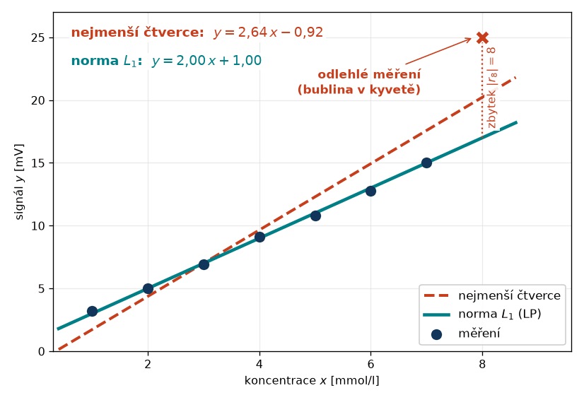

## Kde trik nepomůže

- **celočíselnost** — 0,7 chleba nikdo neupeče, lůžko se neotevře z poloviny a směna se buď koná, nebo ne;
- **buď–anebo** — „linku zapneme, nebo ne“ potřebuje binární $z\in\{0,1\}$;
- **součin proměnných** — $x_1x_2$ není lineární v obou najednou.

Vpravo: kolik lůžek vyčlenit pro plánované výkony ($x_1$) a kolik pro akutní příjmy ($x_2$), aby oddělení ošetřilo co nejvíc pacientů — účel $7x_1+5x_2$.

[figure not shown]

Zaokrouhlení řešení LP není řešení: nahoru $(2,3)$ je nepřípustné, dolů $(1,2)$ obslouží 17 pacientů místo 24. Celočíselné úlohy umí **MILP** solvery (LP relaxace plus větvení) — zápis je stejný, ale cena za vyřešení roste řádově.

## 5 · Geometrie lineárního programu

> Proč se optimum lineární úlohy vždycky schovává v rohu?

## Nadrovina, poloprostor, polyedr

[figure not shown]

Rovnice $\mathbf a^\mathsf T\mathbf x=\beta$ je **nadrovina** (v rovině přímka), nerovnost $\mathbf a^\mathsf T\mathbf x\leq\beta$ **poloprostor** (v rovině polorovina). Každý řádek $A\mathbf x\leq \mathbf b$ ukrojí jednu polovinu prostoru a průnik konečně mnoha poloprostorů je **polyedr** — konvexní množina, protože průnik konvexních množin je konvexní.

## Kam se posouvá vrstevnice

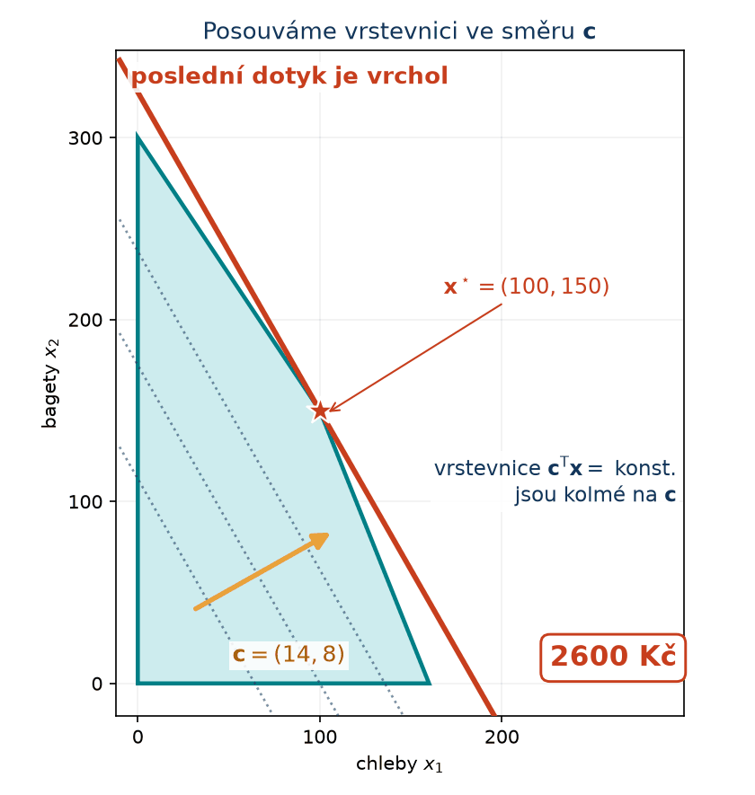

- Body se stejným ziskem tvoří **vrstevnici** $\mathbf c^\mathsf T\mathbf x=\gamma$ — zase nadrovinu.
- Vrstevnice jsou navzájem **rovnoběžné** a **kolmé na $\mathbf c$**.
- Posun ve směru $\mathbf c$ hodnotu zvyšuje, proti směru snižuje.
- Vrstevnici tedy posouváme ve směru $\mathbf c$, dokud se ještě dotýká přípustné oblasti.
- Poslední dotyk leží na hranici — a u polyedru zpravidla přesně v rohu.

## Základní věta lineárního programování

### Extrémní bod (*vertex*)

Bod $\mathbf x\in P$ je **extrémní**, pokud ho nelze zapsat jako netriviální konvexní kombinaci dvou různých přípustných bodů, tedy pokud neexistují $\mathbf y,\mathbf z\in P$, $\mathbf y\neq \mathbf z$, a $\lambda\in(0,1)$ tak, že

$$\mathbf x=\lambda \mathbf y+(1-\lambda)\mathbf z.$$

Intuitivně: roh, který nejde získat **průměrem dvou jiných** přípustných bodů — vnitřní bod ani bod uvnitř hrany to nesplní.

### Věta

Je-li přípustná množina $P=\{\mathbf x:A\mathbf x\leq \mathbf b,\ \mathbf x\geq0\}$ **neprázdná** a je-li na ní účelová funkce $\mathbf c^\mathsf T\mathbf x$ **shora omezená** (u minimalizace zdola), pak optimální řešení existuje a alespoň jedno leží v **extrémním bodě** $P$.

Uvádíme bez důkazu; podstatný je pro nás důsledek dole.

Nezápornost tam musí být: bez ní může polyedr obsahovat celou přímku a pak nemá žádný vrchol — třeba $P=\{\mathbf x:x_1\leq1\}$ v rovině.

To mění způsob hledání: místo nekonečně mnoha přípustných bodů stačí projít **konečně mnoho vrcholů**. Vrchol v $n$ proměnných je určen $n$ lineárně nezávislými aktivními omezeními — v pekárně jsou to mouka a pec a jejich průsečík je $(100,150)$.

## Čtyři možné konce

[figure not shown]

- **Jediné optimum** ve vrcholu — nejčastější případ, stav `optimal`.
- **Celá hrana optim**: vrstevnice je rovnoběžná s hranou; solver vrátí jeden z jejích vrcholů, stav je pořád `optimal`.
- **Neomezená úloha**: zisk roste nade všechny meze — obvykle jsme na nějaké omezení zapomněli; stav `unbounded`.
- **Prázdná přípustná oblast**: omezení si odporují — `infeasible`.

Solver kromě čísel vrací i tenhle stav; `infeasible` a `unbounded` si vyrobíte na cvičení sami.

## 6 · Jak se to řeší

> Dobrá zpráva: tenhle problém už někdo vyřešil za nás. Podívejme se jednou, jak na to jde — a pak toho nechme.

## Simplex: chůze po vrcholech

[figure not shown]

Jeden krok metody v lidské řeči:

1. stojím ve **vrcholu** a znám v něm hodnotu zisku;
2. podívám se po **hranách**, které z vrcholu vedou;
3. jdu po té, po které zisk **roste** — dojdu do sousedního vrcholu;
4. když už žádná taková hrana není, jsem v **optimu**.

Vrcholů je konečně mnoho a zisk se každým krokem zvýší — algoritmus proto musí skončit.

Nejhorší případ simplexu je exponenciální, v praxi bývá počet kroků řádově srovnatelný s počtem omezení. Že je LP řešitelné i v polynomiálním čase, se ukázalo až později a jinými metodami.

## Odbočka: Dantzigův domácí úkol

Simplexovou metodu publikoval **George Dantzig** v roce 1947, když se plánování zásobování americké armády počítalo ještě na papíře a na děrných štítcích.

Slavnější než metoda je historka z jeho studií: přišel pozdě na přednášku ze statistiky, opsal si z tabule dva příklady jako domácí úkol a za pár dní je odevzdal s omluvou, že byly těžší než obvykle. Byly to dva **nevyřešené problémy oboru** — nikdo mu neřekl, že se nedají vyřešit.

Příběh se týká statistiky, ne simplexu; hollywoodská verze je úvodní scéna filmu *Dobrý Will Hunting*.

## Tohle je vyřešený problém

### Co solvery umí navíc

- **Interior-point** metody jdou vnitřkem přípustné oblasti místo po hranách — druhá velká rodina, na velkých úlohách často rychlejší.
- *Presolve*: solver úlohu nejdřív sám zjednoduší — vyhodí nadbytečná omezení a dopočítá proměnné, které jsou beztak pevné.
- Řídká (*sparse*) algebra: z matice s miliony nul se ukládají jen nenuly.

### Proč na LP nepouštět genetický algoritmus

- LP má **konvexní** přípustnou množinu, lineární účel a optimum ve vrcholu; solver toho využije a vrátí řešení i **certifikát optimality**.
- Heuristika o té struktuře neví: dá horší řešení, pomaleji a bez záruky, že lepší neexistuje.
- Metaheuristiky mají smysl tam, kde struktura chybí — nekonvexní, diskrétní nebo *black-box* úlohy.

Implementace solverů píší lidé, kteří tomu věnovali kariéru. Naší prací je **formulace**, ne přepisování solveru — a volba metody se řídí strukturou úlohy, ne módou.

## Ekosystém nástrojů a jedna ukázka

**Solvery** — co doopravdy počítá: HiGHS (výchozí v SciPy), GLPK, Clp; komerční Gurobi, CPLEX, Mosek s akademickou licencí zdarma.

**Modelovací vrstvy** — jak úlohu zapisujeme: CVXPY, PuLP, Pyomo. Model napíšeme jednou, solver se vybere až potom.

Nám bude po celý semestr stačit **CVXPY** s výchozím solverem.

```python
import cvxpy as cp
import numpy as np

c = np.array([14.0, 8.0])          # zisk [Kč/ks]
A = np.array([[0.5, 0.2],          # mouka [kg/ks]
              [3.0, 2.0]])         # pec   [min/ks]
b = np.array([80.0, 600.0])

x = cp.Variable(2, nonneg=True)
uloha = cp.Problem(cp.Maximize(c @ x), [A @ x <= b])
uloha.solve()
```

```
stav řešiče: optimal
x* = [100. 150.]   zisk = 2600 Kč
```

Solver hlásí i stav řešení: kromě `optimal` může přijít `infeasible` nebo `unbounded` — vyzkoušíte na cvičení.

[Zdroj ukázky na GitHubu](https://github.com/tomasvicar/OMM-public/blob/master/prednasky/L2/kod/lp_pekarna_cvxpy.py)

## 7 · Co ze solveru vypadne navíc

> Optimální řešení není jediná odpověď, kterou dostaneme. Solver navíc umí říct, které omezení nás nejvíc bolí — a co by stálo za to dokoupit.

## Stínové ceny

[figure not shown]

Ke každému omezení vrátí solver ještě jedno číslo $y_i$ — **stínovou cenu** (*shadow price*):

$$y_i=\frac{\Delta p^\star}{\Delta b_i}.$$

O kolik se zlepší optimum, když omezení uvolníme o jednotku (pro malou změnu pravé strany $b_i$).

- mouka: $y_1=10$ Kč za kilogram;
- pec: $y_2=3$ Kč za minutu, tedy 180 Kč za hodinu navíc.

Přesně tohle chce vědět manažer i primář: **kam se vyplatí investovat**. Za kilo mouky má smysl zaplatit nejvýš 10 Kč, dráž už se nevrátí.

Omezení, které v optimu **není aktivní**, má stínovou cenu $y_i=0$. Zvětšovat rezervu, kterou stejně nevyčerpáme, nemá cenu — doslova.

## Kdy stínová cena přestává platit

[figure not shown]

Stínová cena je **směrnice** funkce $b_1\mapsto z^\star(b_1)$ — a ta je jen po částech lineární.

- Směrnice se nemění, dokud se nemění **množina aktivních omezení**.
- Tady platí 10 Kč/kg pro $60\leq b_1\leq100$.
- Z dnešních 80 kg tedy: 20 kg navíc přinese 200 Kč. Dvacáté první kilo už nepřinese nic — úzkým hrdlem se stala pec.

Odpovídat na otázky „o kolik a dokdy se to vyplatí“ je *sensitivity analysis*; solvery ji umí vypsat.

## Odkud se stínové ceny berou

### Duální dvojče

Ke každé LP úloze existuje druhá, **duální** úloha, jejíž proměnné jsou právě stínové ceny $\mathbf y$. Pekárna má tuhle:

$$\begin{aligned}
\text{minimize}\quad & 80y_1+600y_2\\
\text{subject to}\quad & 0{,}5y_1+3y_2\geq14\\
& 0{,}2y_1+2y_2\geq8\\
& y_1,y_2\geq0
\end{aligned}$$

První řádek je cena zásob, druhý a třetí patří chlebu a bagetě: zdroje spotřebované jedním kusem musí ve stínových cenách stát aspoň tolik, kolik ten kus vynese. Maticově $\min \mathbf b^\mathsf T\mathbf y$ za $A^\mathsf T\mathbf y\geq \mathbf c$ — role $A$ a $A^\mathsf T$, $\mathbf b$ a $\mathbf c$ se prohodily.

### Certifikát optimality

Každé přípustné $\mathbf y$ dává **horní mez** zisku. Optimum $\mathbf y^\star=(10,3)$ dá

$$\mathbf b^\mathsf T\mathbf y^\star=80\cdot10+600\cdot3=2600 ,$$

tedy přesně dosažený zisk 2600 Kč. Mez se trefila do nalezeného řešení, takže má solver **důkaz**, že lepší plán neexistuje — nemusíme mu věřit na slovo.

Slabou i silnou dualitu, sestavení duální úlohy a komplementární volnost rozebereme **v příští přednášce** u KKT podmínek.

## Co si odnést

1. Lineární program je jediná formulace: $\min \mathbf c^\mathsf T\mathbf x$ za podmínek $A\mathbf x\leq \mathbf b$, $\mathbf x\geq0$ — a překvapivě mnoho úloh do ní jde přeložit.
2. Nejtěžší je **překlad zadání do matic**, ne řešení: řádek $A$ je omezení, sloupec je rozhodovací proměnná.
3. Existuje-li optimum, leží ve **vrcholu** přípustné oblasti; vrchol je dán aktivními omezeními.
4. Vlastní řešení obstará solver — to je vyřešený problém, náš úkol je úloha.
5. Ze solveru vypadne i **cena zdrojů**: stínové ceny říkají, kam investovat a kde je rezerva zbytečná.

Dokážete u nové úlohy říct, **co je řádek matice $A$, co je sloupec** — a jestli je zadání vůbec lineární?

## Rychlá kontrola

1. Podle čeho poznáte, že je úloha lineární? Které dvě vlastnosti musí platit?
2. Co v matici $A$ znamená řádek, co sloupec a co prvek $A_{ij}$?
3. Proč stačí hledat optimum ve vrcholech, když je přípustných bodů nekonečně mnoho?
4. Jak se $\max \mathbf c^\mathsf T\mathbf x$ převede na minimalizaci a co se stane s optimální hodnotou?
5. Co nám o omezení říká stínová cena rovná nule?

## Příště: zakřivený svět — a kde je kód

### Přednáška 3: QP, NLP a KKT

Co když je účelová funkce kvadratická, $\min\tfrac12\mathbf x^\mathsf TQ\mathbf x+\mathbf c^\mathsf T\mathbf x$, nebo je omezení zakřivené?

- optimum už nemusí ležet ve vrcholu — může být uvnitř oblasti nebo kdekoli na zakřivené hranici;
- nástrojem jsou **Lagrangeovy multiplikátory** a **KKT podmínky**, tedy zobecněné stínové ceny;
- naplno se tam vrátí i dualita.

### Zdroje a reprodukovatelný kód

- S. Boyd, L. Vandenberghe: *Convex Optimization*;
- J. Nocedal, S. Wright: *Numerical Optimization*;
- J. Pfrommer a S. L. Brunton — přednáškové kurzy k optimalizaci.

Spustitelné ukázky: [pekárna](https://github.com/tomasvicar/OMM-public/blob/master/prednasky/L2/kod/lp_pekarna_cvxpy.py), [dieta](https://github.com/tomasvicar/OMM-public/blob/master/prednasky/L2/kod/lp_dieta_cvxpy.py), [triky](https://github.com/tomasvicar/OMM-public/blob/master/prednasky/L2/kod/lp_triky_cvxpy.py), [generátor obrázků](https://github.com/tomasvicar/OMM-public/blob/master/prednasky/L2/kod/generuj_obrazky.py) a [evidence ilustrací](https://github.com/tomasvicar/OMM-public/blob/master/prednasky/L2/zdroje.md).